# Выявление закономерностей, определяющих успешность игр

## Описание проекта

Интернет-магазине «Стримчик» продаёт по всему миру компьютерные игры. Из открытых источников доступны исторические данные о продажах игр, оценки пользователей и экспертов, жанры и платформы. Задача - выявить определяющие успешность игр закономерности и разработать рекомендации по развитию наиболее популярного продукта для планирования рекламных кампаний.

### Изучение данных из файлов

```python
import pandas as pd
import numpy as np
from IPython.display import display
import math

from pymystem3 import Mystem
m=Mystem()

import matplotlib.pyplot as plt
%matplotlib inline
pd.set_option('mode.chained_assignment', None) # игнор предупреждений

pd.set_option('display.float_format', '{:,.2f}'.format)

from matplotlib import pyplot as plt
import matplotlib
from math import factorial

from scipy import stats as st
import scipy.stats
from scipy.stats import norm

import seaborn as sns
```

```python
df = pd.read_csv('/datasets/games.csv')
display(df)
```

|  | Name | Platform | Year_of_Release | Genre | NA_sales | EU_sales | JP_sales | Other_sales | Critic_Score | User_Score | Rating |
| --- | --- | --- | --- | --- | --- | --- | --- | --- | --- | --- | --- |
| 0 | Wii Sports | Wii | 2,006.00 | Sports | 41.36 | 28.96 | 3.77 | 8.45 | 76.00 | 8 | E |
| 1 | Super Mario Bros. | NES | 1,985.00 | Platform | 29.08 | 3.58 | 6.81 | 0.77 | NaN | NaN | NaN |
| 2 | Mario Kart Wii | Wii | 2,008.00 | Racing | 15.68 | 12.76 | 3.79 | 3.29 | 82.00 | 8.3 | E |
| 3 | Wii Sports Resort | Wii | 2,009.00 | Sports | 15.61 | 10.93 | 3.28 | 2.95 | 80.00 | 8 | E |
| 4 | Pokemon Red/Pokemon Blue | GB | 1,996.00 | Role-Playing | 11.27 | 8.89 | 10.22 | 1.00 | NaN | NaN | NaN |
| ... | ... | ... | ... | ... | ... | ... | ... | ... | ... | ... | ... |
| 16710 | Samurai Warriors: Sanada Maru | PS3 | 2,016.00 | Action | 0.00 | 0.00 | 0.01 | 0.00 | NaN | NaN | NaN |
| 16711 | LMA Manager 2007 | X360 | 2,006.00 | Sports | 0.00 | 0.01 | 0.00 | 0.00 | NaN | NaN | NaN |
| 16712 | Haitaka no Psychedelica | PSV | 2,016.00 | Adventure | 0.00 | 0.00 | 0.01 | 0.00 | NaN | NaN | NaN |
| 16713 | Spirits & Spells | GBA | 2,003.00 | Platform | 0.01 | 0.00 | 0.00 | 0.00 | NaN | NaN | NaN |
| 16714 | Winning Post 8 2016 | PSV | 2,016.00 | Simulation | 0.00 | 0.00 | 0.01 | 0.00 | NaN | NaN | NaN |

16715 rows × 11 columns

#### Описание данных

- Name — название игры
- Platform — платформа
- Year_of_Release — год выпуска
- Genre — жанр игры
- NA_sales — продажи в Северной Америке (миллионы проданных копий)
- EU_sales — продажи в Европе (миллионы проданных копий)
- JP_sales — продажи в Японии (миллионы проданных копий)
- Other_sales — продажи в других странах (миллионы проданных копий)
- Critic_Score — оценка критиков (максимум 100)
- User_Score — оценка пользователей (максимум 10)
- Rating — рейтинг от организации ESRB (англ. Entertainment Software Rating Board). Эта ассоциация определяет рейтинг компьютерных игр и присваивает им подходящую возрастную категорию.

Аббревиатура ESRB (Entertainment Software Rating Board) — это ассоциация, определяющая возрастной рейтинг компьютерных игр. ESRB оценивает игровой контент и присваивает ему подходящую возрастную категорию, например, «Для взрослых», «Для детей младшего возраста» или «Для подростков».

```python
df.info()
```

```
<class 'pandas.core.frame.DataFrame'>
RangeIndex: 16715 entries, 0 to 16714
Data columns (total 11 columns):
 #   Column           Non-Null Count  Dtype
---  ------           --------------  -----
 0   Name             16713 non-null  object
 1   Platform         16715 non-null  object
 2   Year_of_Release  16446 non-null  float64
 3   Genre            16713 non-null  object
 4   NA_sales         16715 non-null  float64
 5   EU_sales         16715 non-null  float64
 6   JP_sales         16715 non-null  float64
 7   Other_sales      16715 non-null  float64
 8   Critic_Score     8137 non-null   float64
 9   User_Score       10014 non-null  object
 10  Rating           9949 non-null   object
dtypes: float64(6), object(5)
memory usage: 1.4+ MB
```

```python
# цикл для вывода уникальных значений
for column in df.columns:
  display(column, df[column].unique())
```

```
'Name'
```

```
array(['Wii Sports', 'Super Mario Bros.', 'Mario Kart Wii', ...,
       'Woody Woodpecker in Crazy Castle 5', 'LMA Manager 2007',
       'Haitaka no Psychedelica'], dtype=object)
```

```
'Platform'
```

```
array(['Wii', 'NES', 'GB', 'DS', 'X360', 'PS3', 'PS2', 'SNES', 'GBA',
       'PS4', '3DS', 'N64', 'PS', 'XB', 'PC', '2600', 'PSP', 'XOne',
       'WiiU', 'GC', 'GEN', 'DC', 'PSV', 'SAT', 'SCD', 'WS', 'NG', 'TG16',
       '3DO', 'GG', 'PCFX'], dtype=object)
```

```
'Year_of_Release'
```

```
array([2006., 1985., 2008., 2009., 1996., 1989., 1984., 2005., 1999.,
       2007., 2010., 2013., 2004., 1990., 1988., 2002., 2001., 2011.,
       1998., 2015., 2012., 2014., 1992., 1997., 1993., 1994., 1982.,
       2016., 2003., 1986., 2000.,   nan, 1995., 1991., 1981., 1987.,
       1980., 1983.])
```

```
'Genre'
```

```
array(['Sports', 'Platform', 'Racing', 'Role-Playing', 'Puzzle', 'Misc',
       'Shooter', 'Simulation', 'Action', 'Fighting', 'Adventure',
       'Strategy', nan], dtype=object)
```

```
'NA_sales'
```

[output not shown]

[output cut: 12 more lines]

[output not shown]

```
'EU_sales'
```

[output not shown]

```
'JP_sales'
```

[output not shown]

```
'Other_sales'
```

[output not shown]

```
'Critic_Score'
```

```
array([76., nan, 82., 80., 89., 58., 87., 91., 61., 97., 95., 77., 88.,
       83., 94., 93., 85., 86., 98., 96., 90., 84., 73., 74., 78., 92.,
       71., 72., 68., 62., 49., 67., 81., 66., 56., 79., 70., 59., 64.,
       75., 60., 63., 69., 50., 25., 42., 44., 55., 48., 57., 29., 47.,
       65., 54., 20., 53., 37., 38., 33., 52., 30., 32., 43., 45., 51.,
       40., 46., 39., 34., 35., 41., 36., 28., 31., 27., 26., 19., 23.,
       24., 21., 17., 22., 13.])
```

```
'User_Score'
```

```
array(['8', nan, '8.3', '8.5', '6.6', '8.4', '8.6', '7.7', '6.3', '7.4',
       '8.2', '9', '7.9', '8.1', '8.7', '7.1', '3.4', '5.3', '4.8', '3.2',
       '8.9', '6.4', '7.8', '7.5', '2.6', '7.2', '9.2', '7', '7.3', '4.3',
       '7.6', '5.7', '5', '9.1', '6.5', 'tbd', '8.8', '6.9', '9.4', '6.8',
       '6.1', '6.7', '5.4', '4', '4.9', '4.5', '9.3', '6.2', '4.2', '6',
       '3.7', '4.1', '5.8', '5.6', '5.5', '4.4', '4.6', '5.9', '3.9',
       '3.1', '2.9', '5.2', '3.3', '4.7', '5.1', '3.5', '2.5', '1.9', '3',
       '2.7', '2.2', '2', '9.5', '2.1', '3.6', '2.8', '1.8', '3.8', '0',
       '1.6', '9.6', '2.4', '1.7', '1.1', '0.3', '1.5', '0.7', '1.2',
       '2.3', '0.5', '1.3', '0.2', '0.6', '1.4', '0.9', '1', '9.7'],
      dtype=object)
```

```
'Rating'
```

```
array(['E', nan, 'M', 'T', 'E10+', 'K-A', 'AO', 'EC', 'RP'], dtype=object)
```

Заменим названия столбцов (приведем их к нижнему регистру).

```python
df.columns = df.columns.str.lower()
df.info()
```

```
<class 'pandas.core.frame.DataFrame'>
RangeIndex: 16715 entries, 0 to 16714
Data columns (total 11 columns):
 #   Column           Non-Null Count  Dtype
---  ------           --------------  -----
 0   name             16713 non-null  object
 1   platform         16715 non-null  object
 2   year_of_release  16446 non-null  float64
 3   genre            16713 non-null  object
 4   na_sales         16715 non-null  float64
 5   eu_sales         16715 non-null  float64
 6   jp_sales         16715 non-null  float64
 7   other_sales      16715 non-null  float64
 8   critic_score     8137 non-null   float64
 9   user_score       10014 non-null  object
 10  rating           9949 non-null   object
dtypes: float64(6), object(5)
memory usage: 1.4+ MB
```

```python
df['genre'].str.lower().unique()
```

```
array(['sports', 'platform', 'racing', 'role-playing', 'puzzle', 'misc',
       'shooter', 'simulation', 'action', 'fighting', 'adventure',
       'strategy', nan], dtype=object)
```

```python
df['year_of_release'] = df['year_of_release'].astype('Int32') #заменим тип данных на Int
df.info()
```

```
<class 'pandas.core.frame.DataFrame'>
RangeIndex: 16715 entries, 0 to 16714
Data columns (total 11 columns):
 #   Column           Non-Null Count  Dtype
---  ------           --------------  -----
 0   name             16713 non-null  object
 1   platform         16715 non-null  object
 2   year_of_release  16446 non-null  Int32
 3   genre            16713 non-null  object
 4   na_sales         16715 non-null  float64
 5   eu_sales         16715 non-null  float64
 6   jp_sales         16715 non-null  float64
 7   other_sales      16715 non-null  float64
 8   critic_score     8137 non-null   float64
 9   user_score       10014 non-null  object
 10  rating           9949 non-null   object
dtypes: Int32(1), float64(5), object(5)
memory usage: 1.4+ MB
```

В столбце `user_score` есть значение-аббревиатура 'tbd'. Возможно, это t.b.d.= to be defined - подлежит определению. Заменим 'tbd' на NaN, как на не определенные значения в наших данных.

```python
df[df['user_score'] == 'tbd'].count()
```

```
name               2424
platform           2424
year_of_release    2376
genre              2424
na_sales           2424
eu_sales           2424
jp_sales           2424
other_sales        2424
critic_score       1082
user_score         2424
rating             2374
dtype: int64
```

2424 строк со значением 'tbd' в столбце. Изменим тип данных в столбце на числовой. Параметр errors='coerce' принудительно заменит на NaN некорректные значения 'tbd'.

```python
df['user_score'] = pd.to_numeric(df['user_score'], errors='coerce') # `tbd` переводим в NaN
df['user_score'] = df['user_score'].astype('Float32')
df[['na_sales', 'eu_sales', 'jp_sales', 'other_sales']] = df[['na_sales', 'eu_sales', 'jp_sales', 'other_sales']].astype('Float32')
df.info()
```

```
<class 'pandas.core.frame.DataFrame'>
RangeIndex: 16715 entries, 0 to 16714
Data columns (total 11 columns):
 #   Column           Non-Null Count  Dtype
---  ------           --------------  -----
 0   name             16713 non-null  object
 1   platform         16715 non-null  object
 2   year_of_release  16446 non-null  Int32
 3   genre            16713 non-null  object
 4   na_sales         16715 non-null  Float32
 5   eu_sales         16715 non-null  Float32
 6   jp_sales         16715 non-null  Float32
 7   other_sales      16715 non-null  Float32
 8   critic_score     8137 non-null   float64
 9   user_score       7590 non-null   Float32
 10  rating           9949 non-null   object
dtypes: Float32(5), Int32(1), float64(1), object(4)
memory usage: 1.1+ MB
```

Посмотрим пропущенные значения.

```python
df.isna().sum()
```

```
name                  2
platform              0
year_of_release     269
genre                 2
na_sales              0
eu_sales              0
jp_sales              0
other_sales           0
critic_score       8578
user_score         9125
rating             6766
dtype: int64
```

В столбце `name` 2 пропущенных значения. Удалим пропущенные значения.

```python
df.dropna(subset = ['name'], inplace = True)
df.info()
```

```
<class 'pandas.core.frame.DataFrame'>
Int64Index: 16713 entries, 0 to 16714
Data columns (total 11 columns):
 #   Column           Non-Null Count  Dtype
---  ------           --------------  -----
 0   name             16713 non-null  object
 1   platform         16713 non-null  object
 2   year_of_release  16444 non-null  Int32
 3   genre            16713 non-null  object
 4   na_sales         16713 non-null  Float32
 5   eu_sales         16713 non-null  Float32
 6   jp_sales         16713 non-null  Float32
 7   other_sales      16713 non-null  Float32
 8   critic_score     8137 non-null   float64
 9   user_score       7590 non-null   Float32
 10  rating           9949 non-null   object
dtypes: Float32(5), Int32(1), float64(1), object(4)
memory usage: 1.2+ MB
```

Посмотрим: есть ли дубликаты в столбцах `name`, `platform` и `year_of_release`.

```python
df[['name', 'platform', 'year_of_release']].duplicated().sum()
```

```
1
```

Посмотрим на дубликаты и удалим.

```python
df_dupl = df[df[['name', 'platform', 'year_of_release']].duplicated()]
print(format(df_dupl))
```

```
                name platform  year_of_release   genre  na_sales  eu_sales  \
16230  Madden NFL 13      PS3             2012  Sports      0.00      0.01

       jp_sales  other_sales  critic_score  user_score rating
16230      0.00         0.00         83.00        5.50      E
```

Удалим строку 16230 из нашей таблицы.

```python
df.drop(labels = [16230], axis = 0, inplace = True)
df.info()
```

```
<class 'pandas.core.frame.DataFrame'>
Int64Index: 16712 entries, 0 to 16714
Data columns (total 11 columns):
 #   Column           Non-Null Count  Dtype
---  ------           --------------  -----
 0   name             16712 non-null  object
 1   platform         16712 non-null  object
 2   year_of_release  16443 non-null  Int32
 3   genre            16712 non-null  object
 4   na_sales         16712 non-null  Float32
 5   eu_sales         16712 non-null  Float32
 6   jp_sales         16712 non-null  Float32
 7   other_sales      16712 non-null  Float32
 8   critic_score     8136 non-null   float64
 9   user_score       7589 non-null   Float32
 10  rating           9948 non-null   object
dtypes: Float32(5), Int32(1), float64(1), object(4)
memory usage: 1.2+ MB
```

```python
df['rating'] = df['rating'].fillna('unknown')
df.isna().sum()
```

```
name                  0
platform              0
year_of_release     269
genre                 0
na_sales              0
eu_sales              0
jp_sales              0
other_sales           0
critic_score       8576
user_score         9123
rating                0
dtype: int64
```

```python
df.head()
```

|  | name | platform | year_of_release | genre | na_sales | eu_sales | jp_sales | other_sales | critic_score | user_score | rating |
| --- | --- | --- | --- | --- | --- | --- | --- | --- | --- | --- | --- |
| 0 | Wii Sports | Wii | 2006 | Sports | 41.36 | 28.96 | 3.77 | 8.45 | 76.00 | 8.00 | E |
| 1 | Super Mario Bros. | NES | 1985 | Platform | 29.08 | 3.58 | 6.81 | 0.77 | NaN | <NA> | unknown |
| 2 | Mario Kart Wii | Wii | 2008 | Racing | 15.68 | 12.76 | 3.79 | 3.29 | 82.00 | 8.30 | E |
| 3 | Wii Sports Resort | Wii | 2009 | Sports | 15.61 | 10.93 | 3.28 | 2.95 | 80.00 | 8.00 | E |
| 4 | Pokemon Red/Pokemon Blue | GB | 1996 | Role-Playing | 11.27 | 8.89 | 10.22 | 1.00 | NaN | <NA> | unknown |

Посчитаем суммарные продажи во всех регионах и запишем их в столбец `all_sales`.

```python
df['all_sales'] = df['na_sales'] + df['eu_sales'] + df['jp_sales'] + df['other_sales']
df.sample()
```

|  | name | platform | year_of_release | genre | na_sales | eu_sales | jp_sales | other_sales | critic_score | user_score | rating | all_sales |
| --- | --- | --- | --- | --- | --- | --- | --- | --- | --- | --- | --- | --- |
| 4351 | F.E.A.R. 3 | PS3 | 2011 | Shooter | 0.21 | 0.16 | 0.01 | 0.07 | 74.00 | 7.10 | M | 0.45 |

```python
df['user_score_new'] = df['user_score'] * 10
```

```python
temp = df.copy()
list_c = ['name', 'platform', 'year_of_release', 'genre', 'critic_score', 'user_score', 'rating']
print(temp.info())
for col_l in list_c:
  print('-------------------------')
  print(col_l, temp[col_l].sort_values().unique())
  print(col_l,': кол-во NaN',temp[col_l].isna().sum(),', процент NaN', round(temp[col_l].isna().sum()/len(temp)*100, 2),'%')
```

```
<class 'pandas.core.frame.DataFrame'>
Int64Index: 16712 entries, 0 to 16714
Data columns (total 13 columns):
 #   Column           Non-Null Count  Dtype
---  ------           --------------  -----
 0   name             16712 non-null  object
 1   platform         16712 non-null  object
 2   year_of_release  16443 non-null  Int32
 3   genre            16712 non-null  object
 4   na_sales         16712 non-null  Float32
 5   eu_sales         16712 non-null  Float32
 6   jp_sales         16712 non-null  Float32
 7   other_sales      16712 non-null  Float32
 8   critic_score     8136 non-null   float64
 9   user_score       7589 non-null   Float32
 10  rating           16712 non-null  object
 11  all_sales        16712 non-null  Float32
 12  user_score_new   7589 non-null   Float32
dtypes: Float32(7), Int32(1), float64(1), object(4)
memory usage: 1.4+ MB
None
-------------------------
name [' Beyblade Burst' ' Fire Emblem Fates' " Frozen: Olaf's Quest" ...
 'uDraw Studio: Instant Artist' 'wwe Smackdown vs. Raw 2006'
 '¡Shin Chan Flipa en colores!']
name : кол-во NaN 0 , процент NaN 0.0 %
-------------------------
platform ['2600' '3DO' '3DS' 'DC' 'DS' 'GB' 'GBA' 'GC' 'GEN' 'GG' 'N64' 'NES' 'NG'
 'PC' 'PCFX' 'PS' 'PS2' 'PS3' 'PS4' 'PSP' 'PSV' 'SAT' 'SCD' 'SNES' 'TG16'
 'WS' 'Wii' 'WiiU' 'X360' 'XB' 'XOne']
platform : кол-во NaN 0 , процент NaN 0.0 %
-------------------------
year_of_release <IntegerArray>
[1980, 1981, 1982, 1983, 1984, 1985, 1986, 1987, 1988, 1989, 1990, 1991, 1992,
 1993, 1994, 1995, 1996, 1997, 1998, 1999, 2000, 2001, 2002, 2003, 2004, 2005,
 2006, 2007, 2008, 2009, 2010, 2011, 2012, 2013, 2014, 2015, 2016, <NA>]
Length: 38, dtype: Int32
year_of_release : кол-во NaN 269 , процент NaN 1.61 %
-------------------------
genre ['Action' 'Adventure' 'Fighting' 'Misc' 'Platform' 'Puzzle' 'Racing'
```

[output cut: 9 more lines]

```
-------------------------
user_score <FloatingArray>
[ 0.0,  0.2,  0.3,  0.5,  0.6,  0.7,  0.9,  1.0,  1.1,  1.2,  1.3,  1.4,  1.5,
  1.6,  1.7,  1.8,  1.9,  2.0,  2.1,  2.2,  2.3,  2.4,  2.5,  2.6,  2.7,  2.8,
  2.9,  3.0,  3.1,  3.2,  3.3,  3.4,  3.5,  3.6,  3.7,  3.8,  3.9,  4.0,  4.1,
  4.2,  4.3,  4.4,  4.5,  4.6,  4.7,  4.8,  4.9,  5.0,  5.1,  5.2,  5.3,  5.4,
  5.5,  5.6,  5.7,  5.8,  5.9,  6.0,  6.1,  6.2,  6.3,  6.4,  6.5,  6.6,  6.7,
  6.8,  6.9,  7.0,  7.1,  7.2,  7.3,  7.4,  7.5,  7.6,  7.7,  7.8,  7.9,  8.0,
  8.1,  8.2,  8.3,  8.4,  8.5,  8.6,  8.7,  8.8,  8.9,  9.0,  9.1,  9.2,  9.3,
  9.4,  9.5,  9.6,  9.7, <NA>]
Length: 96, dtype: Float32
user_score : кол-во NaN 9123 , процент NaN 54.59 %
-------------------------
rating ['AO' 'E' 'E10+' 'EC' 'K-A' 'M' 'RP' 'T' 'unknown']
rating : кол-во NaN 0 , процент NaN 0.0 %
```

Удалим пропуски в столбце `year_of_release`, поскольку это ключевые данные, по которым мы в дальнейшем будем делать отбор наших данных.

```python
df.dropna(subset = ['year_of_release'], inplace = True)
df.info()
```

```
<class 'pandas.core.frame.DataFrame'>
Int64Index: 16443 entries, 0 to 16714
Data columns (total 13 columns):
 #   Column           Non-Null Count  Dtype
---  ------           --------------  -----
 0   name             16443 non-null  object
 1   platform         16443 non-null  object
 2   year_of_release  16443 non-null  Int32
 3   genre            16443 non-null  object
 4   na_sales         16443 non-null  Float32
 5   eu_sales         16443 non-null  Float32
 6   jp_sales         16443 non-null  Float32
 7   other_sales      16443 non-null  Float32
 8   critic_score     7982 non-null   float64
 9   user_score       7462 non-null   Float32
 10  rating           16443 non-null  object
 11  all_sales        16443 non-null  Float32
 12  user_score_new   7462 non-null   Float32
dtypes: Float32(7), Int32(1), float64(1), object(4)
memory usage: 1.4+ MB
```

## Исследовательский анализ данных

### Выпуск игр по годам

Посмотрим, сколько игр выпускалось в разные годы и определим важны ли данные за все периоды.

```python
# games_years = df.groupby('year_of_release')['name'].count().plot()
games_years = df.groupby('year_of_release')['name'].count()
games_years
```

```
year_of_release
1980       9
1981      46
1982      36
1983      17
1984      14
1985      14
1986      21
1987      16
1988      15
1989      17
1990      16
1991      41
1992      43
1993      60
```

[output cut: 24 more lines]

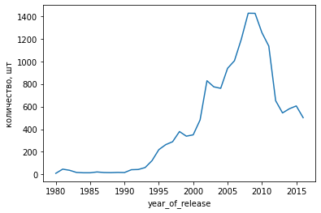

```python
games_years.plot()
plt.ylabel('количество, шт')
plt.show()
```

В период с 1980 по 1993 гг выпускалось мало игр (до 100) относительно всего дальнейшего периода. Этот период можно не учитывать в нашем дальнейшем исследовании. Отбросив его, мы получим картину почти нормального распределения наших данных. Пик выпуска игр приходится на период 2008-2009 гг. Дальнейший период - в целом период спада с небольшим пиком в 2015 г.

### Изменения продаж по платформам

Посмотрим, как менялись продажи по платформам. Выберем платформы с наибольшими суммарными продажами и построим распределение по годам. Ответим на вопрос: за какой характерный срок появляются новые и исчезают старые платформы.

```python
platforms_sales = df.groupby('platform')['all_sales'].count().sort_values(ascending = False)
# platforms_sales.sort_values(ascending = False)
platforms_sales
```

```
platform
PS2     2127
DS      2121
PS3     1305
Wii     1286
X360    1232
PSP     1193
PS      1190
PC       957
GBA      811
XB       803
GC       542
3DS      512
PSV      429
PS4      392
N64      316
XOne     247
SNES     239
SAT      173
WiiU     147
2600     116
NES       98
GB        97
DC        52
GEN       27
NG        12
SCD        6
WS         6
3DO        3
TG16       2
PCFX       1
GG         1
Name: all_sales, dtype: int64
```

```python
top_platforms = df[df['platform'].isin(platforms_sales.index[:10])].pivot_table(index='year_of_release', columns='platform', values='name', aggfunc='count')
top_platforms
```

| platform year_of_release | DS | GBA | PC | PS | PS2 | PS3 | PSP | Wii | X360 | XB |
| --- | --- | --- | --- | --- | --- | --- | --- | --- | --- | --- |
| 1985 | 1.00 | NaN | 1.00 | NaN | NaN | NaN | NaN | NaN | NaN | NaN |
| 1988 | NaN | NaN | 1.00 | NaN | NaN | NaN | NaN | NaN | NaN | NaN |
| 1992 | NaN | NaN | 5.00 | NaN | NaN | NaN | NaN | NaN | NaN | NaN |
| 1994 | NaN | NaN | 6.00 | 17.00 | NaN | NaN | NaN | NaN | NaN | NaN |
| 1995 | NaN | NaN | 2.00 | 99.00 | NaN | NaN | NaN | NaN | NaN | NaN |
| 1996 | NaN | NaN | 4.00 | 164.00 | NaN | NaN | NaN | NaN | NaN | NaN |
| 1997 | NaN | NaN | 6.00 | 188.00 | NaN | NaN | NaN | NaN | NaN | NaN |
| 1998 | NaN | NaN | 8.00 | 248.00 | NaN | NaN | NaN | NaN | NaN | NaN |
| 1999 | NaN | NaN | 7.00 | 200.00 | NaN | NaN | NaN | NaN | NaN | NaN |
| 2000 | NaN | 1.00 | 7.00 | 160.00 | 82.00 | NaN | NaN | NaN | NaN | 1.00 |
| 2001 | NaN | 107.00 | 15.00 | 91.00 | 185.00 | NaN | NaN | NaN | NaN | 33.00 |
| 2002 | NaN | 198.00 | 19.00 | 20.00 | 280.00 | NaN | NaN | NaN | NaN | 158.00 |
| 2003 | NaN | 150.00 | 33.00 | 3.00 | 256.00 | NaN | NaN | NaN | NaN | 189.00 |
| 2004 | 23.00 | 175.00 | 30.00 | NaN | 259.00 | NaN | 15.00 | NaN | NaN | 177.00 |
| 2005 | 118.00 | 135.00 | 37.00 | NaN | 260.00 | NaN | 95.00 | NaN | 18.00 | 179.00 |
| 2006 | 201.00 | 39.00 | 52.00 | NaN | 259.00 | 27.00 | 189.00 | 44.00 | 93.00 | 62.00 |
| 2007 | 376.00 | 6.00 | 62.00 | NaN | 214.00 | 90.00 | 133.00 | 185.00 | 123.00 | 3.00 |
| 2008 | 492.00 | NaN | 76.00 | NaN | 191.00 | 138.00 | 100.00 | 282.00 | 146.00 | 1.00 |
| 2009 | 403.00 | NaN | 107.00 | NaN | 96.00 | 162.00 | 161.00 | 325.00 | 172.00 | NaN |
| 2010 | 323.00 | NaN | 90.00 | NaN | 38.00 | 181.00 | 188.00 | 253.00 | 182.00 | NaN |
| 2011 | 153.00 | NaN | 139.00 | NaN | 7.00 | 215.00 | 139.00 | 143.00 | 206.00 | NaN |
| 2012 | 23.00 | NaN | 61.00 | NaN | NaN | 147.00 | 106.00 | 31.00 | 106.00 | NaN |
| 2013 | 8.00 | NaN | 38.00 | NaN | NaN | 126.00 | 54.00 | 12.00 | 75.00 | NaN |
| 2014 | NaN | NaN | 47.00 | NaN | NaN | 108.00 | 10.00 | 6.00 | 63.00 | NaN |
| 2015 | NaN | NaN | 50.00 | NaN | NaN | 73.00 | 3.00 | 4.00 | 35.00 | NaN |
| 2016 | NaN | NaN | 54.00 | NaN | NaN | 38.00 | NaN | 1.00 | 13.00 | NaN |

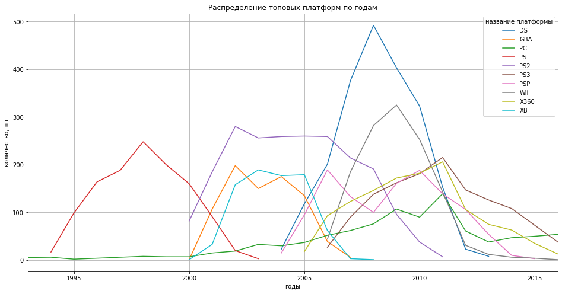

```python
top_platforms.plot(grid=True, figsize=(16,8), xlim=(1993,2016))
plt.legend(title ='название платформы')
plt.title('Распределение топовых платформ по годам')
plt.xlabel('годы')
plt.ylabel('количество, шт')
plt.show()
```

Платформы доминируют в своей популярности в течение некоторого периода времени, сменяя друг друга или появляясь одновременно на рынке. Исходя из табличных данных и графиков, средний срок жизнеспособности игровой платформы составляет около 10 лет. (Для платформы PC данные за 1994-2000 гг можно отбросить, так как выпуск игр для этой платформы находился в районе нулевых значений).

Создадим таблицу `df_prediction` с данными за эти годы.

```python
df_prediction = df[df['year_of_release'] >= 2013]
df_prediction.info()
```

```
<class 'pandas.core.frame.DataFrame'>
Int64Index: 2233 entries, 16 to 16714
Data columns (total 13 columns):
 #   Column           Non-Null Count  Dtype
---  ------           --------------  -----
 0   name             2233 non-null   object
 1   platform         2233 non-null   object
 2   year_of_release  2233 non-null   Int32
 3   genre            2233 non-null   object
 4   na_sales         2233 non-null   Float32
 5   eu_sales         2233 non-null   Float32
 6   jp_sales         2233 non-null   Float32
 7   other_sales      2233 non-null   Float32
 8   critic_score     991 non-null    float64
 9   user_score       1192 non-null   Float32
 10  rating           2233 non-null   object
 11  all_sales        2233 non-null   Float32
 12  user_score_new   1192 non-null   Float32
dtypes: Float32(7), Int32(1), float64(1), object(4)
memory usage: 191.9+ KB
```

Посмотрим, какие платформы лидируют по продажам.

Обратимся к наиболее четкой метрике доходности платформ - объему суммарных продаж. Сгруппируем нашу новую таблицу и построим график.

```python
df_prediction.groupby(['platform', 'year_of_release'])['all_sales'].sum().unstack('platform')
```

| platform year_of_release | 3DS | DS | PC | PS3 | PS4 | PSP | PSV | Wii | WiiU | X360 | XOne |
| --- | --- | --- | --- | --- | --- | --- | --- | --- | --- | --- | --- |
| 2013 | 56.57 | 1.54 | 12.38 | 113.25 | 25.99 | 3.14 | 10.59 | 8.59 | 21.65 | 88.58 | 18.96 |
| 2014 | 43.76 | <NA> | 13.28 | 47.76 | 100.00 | 0.24 | 11.90 | 3.75 | 22.03 | 34.74 | 54.07 |
| 2015 | 27.78 | <NA> | 8.52 | 16.82 | 118.90 | 0.12 | 6.25 | 1.14 | 16.35 | 11.96 | 60.14 |
| 2016 | 15.14 | <NA> | 5.25 | 3.60 | 69.25 | <NA> | 4.25 | 0.18 | 4.60 | 1.52 | 26.15 |

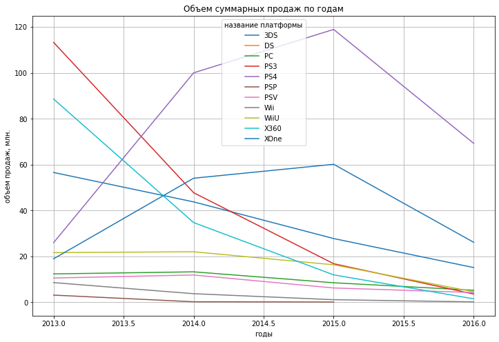

```python
df_prediction_groupby = df_prediction.groupby(['platform', 'year_of_release'])['all_sales'].sum().unstack('platform').plot(grid=True, figsize=(12,8))
title='Объем суммарных продаж по годам',
plt.legend(title = 'название платформы')
plt.title('Объем суммарных продаж по годам')
plt.xlabel('годы')
plt.ylabel('объем продаж, млн.')
plt.show()
```

Лидерами продаж выступают платформы: PS4, XOne, PS3, 3DS, X360. Все объемы продаж платформ падают с 2015 года.

### «Ящик с усами» по глобальным продажам игр в разбивке по платформам

Построим график «ящик с усами» по глобальным продажам игр в разбивке по платформам. Возьмем данные за весь период существования данных платформ.

```python
top_platforms_all = df[df['platform'].isin(('DS', '3DS', 'PC', 'X360', 'XOne', 'PS4', 'PS3', 'Wii', 'WiiU', 'PSP', 'PSV'))]
```

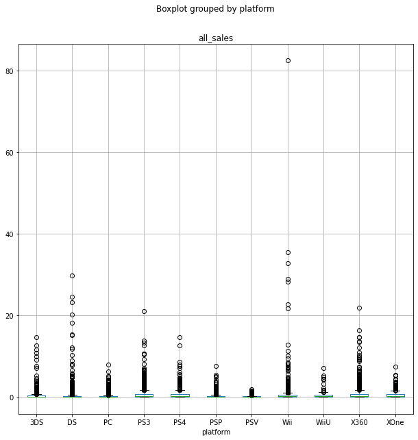

```python
top_platforms_all.boxplot(column='all_sales', by='platform', figsize=(10, 10))
# plt.ylim(0, 2)
plt.show()
```

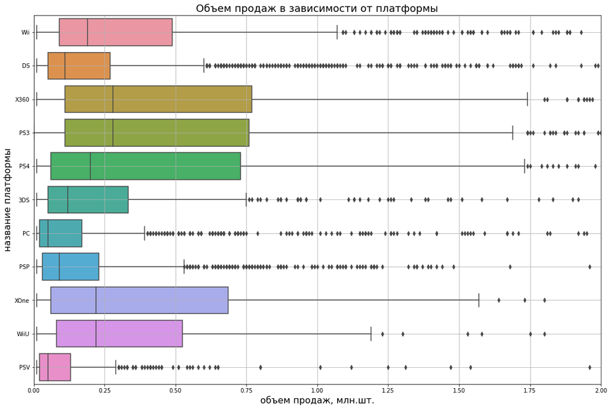

```python
plt.figure(figsize=(18,12))
ax = sns.boxplot(
    y='platform',
    x='all_sales',
    data=top_platforms_all,
    orient='h'
)
ax.grid(which='both')
plt.xlabel('объем продаж, млн.шт.', fontsize=16)
plt.ylabel('название платформы', fontsize=16)
plt.title('Объем продаж в зависимости от платформы', fontsize=18)
ax.set(xlim=(0, 2))
plt.show()
```

Выбросы-максимальные значения показывают успешные продажи игр.

Потенциально прибыльными платформами будем считать X360, PS4, XOne, PS3, Wii, WiiU, у которых медиана больше 0.12 и Q3 больше 0.45.

Создадим таблицу `df_prediction_vyborka` для дальнейшего исследования, взяв только эти платформы.

```python
df_prediction_vyborka = df_prediction[df_prediction['platform'].isin(('X360', 'XOne', 'PS4', 'PS3', 'Wii', 'WiiU'))]
```

### Влияние отзывов пользователей и критиков на продажи платформы `X360`

Посмотрим, как влияют на продажи внутри одной популярной платформы отзывы пользователей и критиков. Построим диаграмму рассеяния и посчитаем корреляцию между отзывами и продажами.

Возьмем одну из самых прибыльных платформ `X360`.

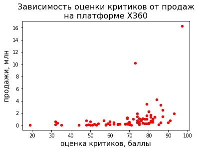

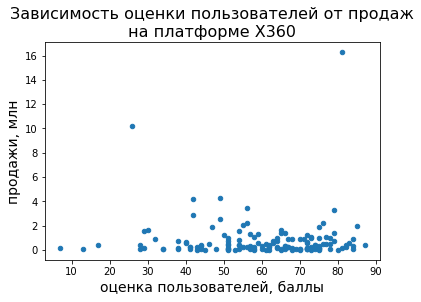

```python
df_x360 = df_prediction_vyborka[df_prediction_vyborka['platform'] == 'X360']
df_x360.plot(x='critic_score', y='all_sales', kind='scatter', color='red')
plt.xlabel('оценка критиков, баллы', fontsize=14)
plt.ylabel('продажи, млн', fontsize=14)
plt.title('Зависимость оценки критиков от продаж\nна платформе X360', fontsize=16)

df_x360.plot(x='user_score_new', y='all_sales', kind='scatter')
plt.xlabel('оценка пользователей, баллы', fontsize=14)
plt.ylabel('продажи, млн', fontsize=14)
plt.title('Зависимость оценки пользователей от продаж\nна платформе X360', fontsize=16)
plt.show()
```

```python
df_x360[['critic_score', 'all_sales']].corr()
```

|  | critic_score | all_sales |
| --- | --- | --- |
| critic_score | 1.00 | 0.35 |
| all_sales | 0.35 | 1.00 |

```python
df_x360[['user_score_new', 'all_sales']].corr()
```

|  | user_score_new | all_sales |
| --- | --- | --- |
| user_score_new | 1.00 | -0.01 |
| all_sales | -0.01 | 1.00 |

Коэффициенты корреляции между продажами и отзывами критиков и пользователей меньше 0.5, выводы о какой-либо явной взаимосвязи мы сделать не можем, хотя по диаграмме рассеивания видны некоторые закономерности. Исключив выбросы, получим следующие коэффициенты корреляции.

```python
df_x360_cut = df_x360[df_x360['all_sales'] < 1.75]
df_x360_cut[['critic_score', 'all_sales']].corr()
```

|  | critic_score | all_sales |
| --- | --- | --- |
| critic_score | 1.00 | 0.47 |
| all_sales | 0.47 | 1.00 |

```python
df_x360_cut[['user_score_new', 'all_sales']].corr()
```

|  | user_score_new | all_sales |
| --- | --- | --- |
| user_score_new | 1.00 | 0.04 |
| all_sales | 0.04 | 1.00 |

Коэффициенты выросли после очистки выбросов, но очевидной взаимосвязи между продажами и отзывами также не наблюдается (хотя у оценок критиков и продаж есть умеренная корреляция 0.47).

### Влияние отзывов пользователей и критиков на продажи остальных платформ

`df_rest` - таблица остальных платформ из нашей итоговой выборки.

```python
df_rest = df_prediction_vyborka.query('platform != "X360"')
```

Построим диаграммы рассеяния и посчитаем корреляции между отзывами и продажами на этих платформах.

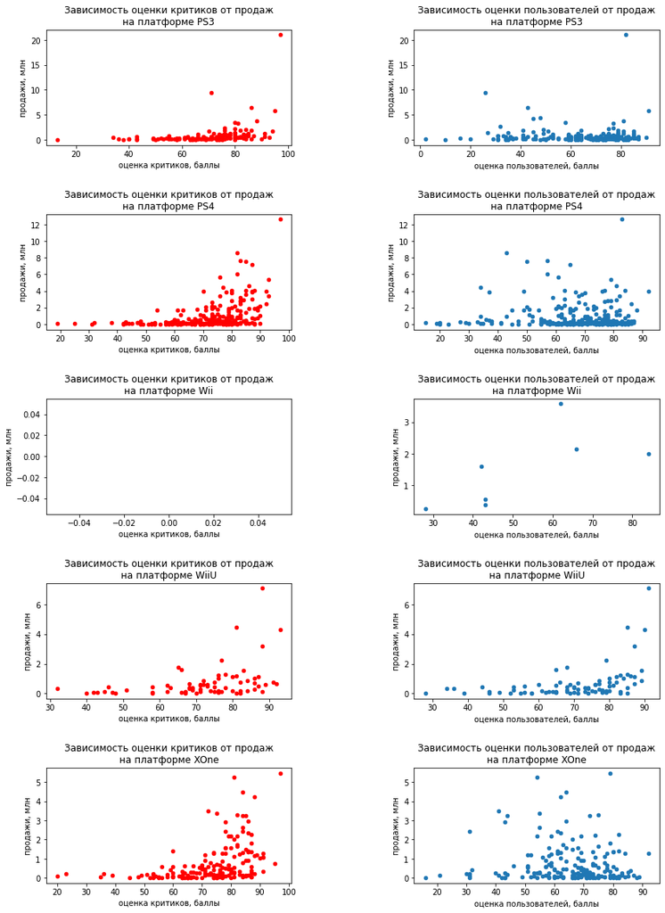

```
Коэффициенты корреляции между продажами и отзывами критиков:
                        all_sales  critic_score
platform
PS3      all_sales          1.00          0.33
         critic_score       0.33          1.00
PS4      all_sales          1.00          0.41
         critic_score       0.41          1.00
Wii      all_sales          1.00           NaN
         critic_score        NaN           NaN
WiiU     all_sales          1.00          0.38
         critic_score       0.38          1.00
XOne     all_sales          1.00          0.42
         critic_score       0.42          1.00

Коэффициенты корреляции между продажами и отзывами пользователей:
                          all_sales  user_score_new
platform
PS3      all_sales            1.00            0.00
         user_score_new       0.00            1.00
PS4      all_sales            1.00           -0.03
         user_score_new      -0.03            1.00
Wii      all_sales            1.00            0.68
         user_score_new       0.68            1.00
WiiU     all_sales            1.00            0.42
         user_score_new       0.42            1.00
XOne     all_sales            1.00           -0.07
         user_score_new      -0.07            1.00
```

```python
fig, axs = plt.subplots(5, 2, figsize=(14,20))
for i, platforms in enumerate(df_rest.groupby('platform')):
    platforms[1].plot(kind='scatter', x='critic_score', y='all_sales', color='red',
                      title = 'Зависимость оценки критиков от продаж\nна платформе {}'.format(platforms[0]),
                      alpha=1, ax=axs[i, 0])
    platforms[1].plot(kind='scatter', x='user_score_new', y='all_sales',
                      title = 'Зависимость оценки пользователей от продаж\nна платформе {}'.format(platforms[0]),
                      alpha=1, ax=axs[i, 1])
    axs[i][0].set_xlabel('оценка критиков, баллы')
    axs[i][1].set_xlabel('оценка пользователей, баллы')
    axs[i][0].set_ylabel('продажи, млн')
    axs[i][1].set_ylabel('продажи, млн')
    plt.subplots_adjust(wspace=0.5, hspace=0.6)
plt.show()

print('Коэффициенты корреляции между продажами и отзывами критиков:\n',
      df_rest.groupby('platform')[['all_sales', 'critic_score']].corr())
print('\nКоэффициенты корреляции между продажами и отзывами пользователей:\n',
      df_rest.groupby('platform')[['all_sales', 'user_score_new']].corr())
```

Явной взаимосвязи между продажами и отзывами для остальных платформ также не наблюдается. Коэффициенты корреляции везде меньше 0.5, что по шкале Чеддока показывает о наличии слабой силы связей. Исключение составляет коэффициент корреляции между продажами и отзывами пользователей на платформе Wii, но, как мы видим, данных не достаточно для того, чтобы принять этот результат во внимание (всего 7 точек).

### Общее распределение игр по жанрам

Посмотрим на общее распределение игр по жанрам.

Создадим сводную таблицу `df_genre` распределения игр по жанрам с учетом суммарных продаж и общего количества и построим гистограммы.

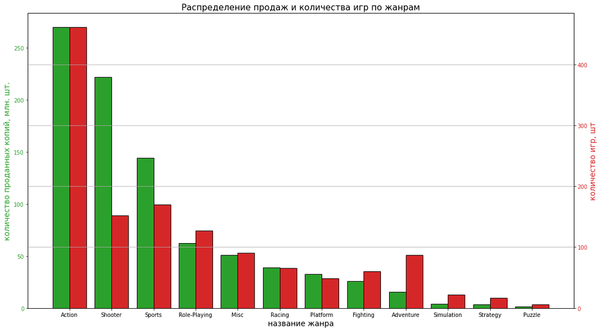

```python
df_genre = df_prediction_vyborka.groupby('genre').agg({'name' : 'count',
                                                       'all_sales' : 'sum'}).sort_values(by  = 'all_sales',
                                                                                         ascending = False).reset_index()

df_genre.columns = ['genre', 'quantity', 'all_sales']

fig, ax1 = plt.subplots(figsize = (18,10))
width = 0.4
x = np.arange(len(df_genre))
color = 'tab:green'
ax1.set_ylabel('количество проданных копий, млн. шт.', color=color, fontsize=14)
ax1.bar(x - 0.20, df_genre['all_sales'], color=color, width=width, ec='black')
ax1.tick_params(axis='y', labelcolor=color)
ax1.set_xlabel('название жанра', fontsize=14)

ax2 = ax1.twinx()

color = 'tab:red'
ax2.set_ylabel('количество игр, шт', color=color, fontsize=14)
ax2.bar(x + 0.20, df_genre['quantity'], color=color, width=width, ec='black')
ax2.tick_params(axis='y', labelcolor=color)
plt.rcParams['font.size'] = '13'
plt.xticks(df_genre.index, df_genre.genre)
plt.grid(True)
plt.title('Распределение продаж и количества игр по жанрам')
```

```python
df_genre
```

|  | genre | quantity | all_sales |
| --- | --- | --- | --- |
| 0 | Action | 461 | 269.49 |
| 1 | Shooter | 152 | 221.64 |
| 2 | Sports | 170 | 144.07 |
| 3 | Role-Playing | 127 | 62.39 |
| 4 | Misc | 91 | 50.91 |
| 5 | Racing | 66 | 38.82 |
| 6 | Platform | 49 | 32.61 |
| 7 | Fighting | 60 | 25.79 |
| 8 | Adventure | 87 | 15.61 |
| 9 | Simulation | 22 | 3.86 |
| 10 | Strategy | 17 | 3.41 |
| 11 | Puzzle | 6 | 1.38 |

Исходя из таблицы и гистограмм, жанр `Action` является лидером по суммарным продажам и количеству игр в ассортименте. `Shooter`и `Sports` занимают вторую и третью позицию по суммарным продажам в жанрах. Самые низкие продажи в жанрах `Puzzle`, `Strategy` и `Simulation`.

Посмотрим на распределения в boxplot.

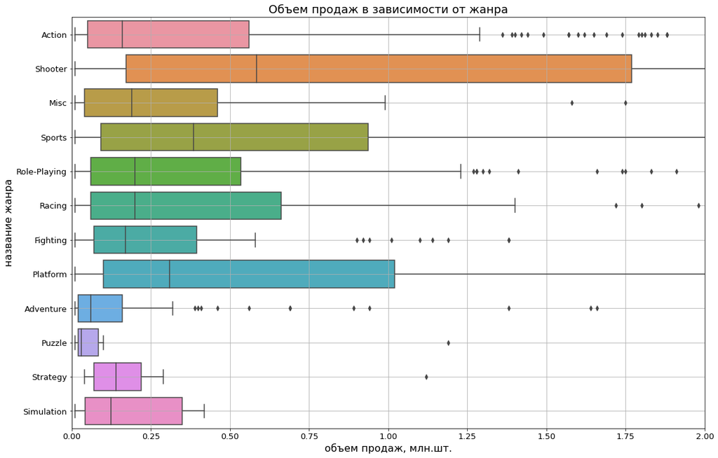

```python
plt.figure(figsize=(18,12))
ax = sns.boxplot(
    y='genre',
    x='all_sales',
    data=df_prediction_vyborka,
    orient='h'
)
ax.grid(which='both')
plt.xlabel('объем продаж, млн.шт.', fontsize=16)
plt.ylabel('название жанра', fontsize=16)
plt.title('Объем продаж в зависимости от жанра', fontsize=18)
ax.set(xlim=(0, 2))
plt.show()
```

Мы видим, что самые высокие по медиане объемы продаж находятся в жанре `Shooter`, затем идут `Sport` и `Platform`, а `Action` поднимался в топ-гистограмм из-за "выбросов". В `Strategy` и `Simulation` медианные значения объемов продаж сравнимы с `Action`. Наименее популярные продажи в жанре `Puzzle`.

Вернуться в начало.

## Портрет пользователя каждого региона

Определим для пользователя каждого региона (NA, EU, JP):

- Самые популярные платформы (топ-5).
- Самые популярные жанры (топ-5).
- Посмотрим, влияет ли рейтинг ESRB на продажи в отдельном регионе.

### Самые популярные платформы (топ-5)

Построим график распределения суммарных продаж топовых игр в регионах по платформам.

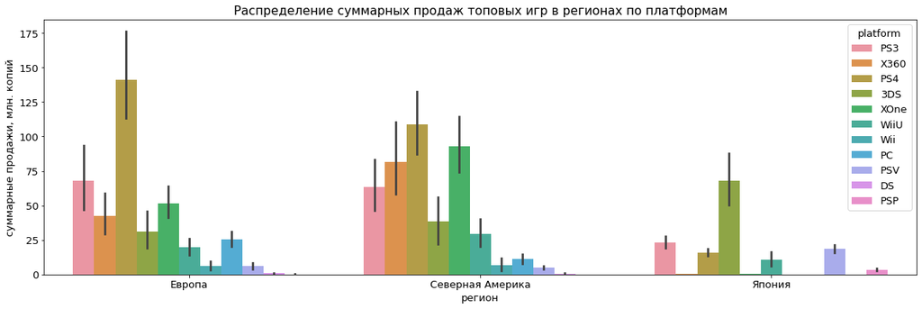

```python
regions_platform_melt = pd.melt(df_prediction, id_vars=['platform'], value_vars=['eu_sales', 'na_sales', 'jp_sales'])
regions_platform_melt.columns = ['platform', 'region', 'sales']
regions_platform_melt.replace({'eu_sales': 'Европа', 'jp_sales': 'Япония', 'na_sales': 'Северная Америка'}, inplace=True)

plt.figure(figsize=(20,6))

sns.barplot(data = regions_platform_melt, x='region', y='sales', hue='platform', estimator=sum)
sns.set_style("whitegrid")

plt.xlabel('регион')
plt.ylabel('суммарные продажи, млн. копий')
plt.title('Распределение суммарных продаж топовых игр в регионах по платформам')
```

Создадим таблицу `all_platform` и столбец `percent_all_sales`, куда поместим расчетные доли продаж каждой платформы от общих продаж всех платформ в мире.

```python
all_platform = df_prediction.groupby('platform').agg({'all_sales' : 'sum'}).sort_values(by  = 'all_sales',
                                                                                         ascending = False).reset_index()
all_platform['percent_all_sales'] = all_platform['all_sales'] / all_platform['all_sales'].sum() * 100
all_platform
```

|  | platform | all_sales | percent_all_sales |
| --- | --- | --- | --- |
| 0 | PS4 | 314.14 | 28.80 |
| 1 | PS3 | 181.43 | 16.63 |
| 2 | XOne | 159.32 | 14.61 |
| 3 | 3DS | 143.25 | 13.13 |
| 4 | X360 | 136.80 | 12.54 |
| 5 | WiiU | 64.63 | 5.93 |
| 6 | PC | 39.43 | 3.62 |
| 7 | PSV | 32.99 | 3.02 |
| 8 | Wii | 13.66 | 1.25 |
| 9 | PSP | 3.50 | 0.32 |
| 10 | DS | 1.54 | 0.14 |

#### Северная Америка (NA)

Создадим таблицу, куда включим только данные продаж по региону Северная Америка.

```python
df_prediction_na = df_prediction.query('na_sales > 0')
df_prediction_na.sample()
```

|  | name | platform | year_of_release | genre | na_sales | eu_sales | jp_sales | other_sales | critic_score | user_score | rating | all_sales | user_score_new |
| --- | --- | --- | --- | --- | --- | --- | --- | --- | --- | --- | --- | --- | --- |
| 1817 | The Legend of Zelda: Tri Force Heroes | 3DS | 2015 | Action | 0.53 | 0.33 | 0.17 | 0.08 | 73.00 | 7.60 | E | 1.11 | 76.00 |

Сгруппируем данные по платформам, отортируем по убыванию, создадим столбец, где расчитаем долю продаж каждой платформы от суммарных общих продаж в регионе и выделим топ-5 платформ.

```python
top_platform_na = df_prediction_na.groupby('platform').agg({'na_sales' : 'sum',
                                                            'all_sales' : 'sum'}).sort_values(by  = 'na_sales',
                                                                                         ascending = False).reset_index()
top_platform_na['share_of_all_sales_na'] = top_platform_na['na_sales'] / top_platform_na['na_sales'].sum() * 100
top_platform_na = top_platform_na[['platform', 'na_sales', 'share_of_all_sales_na']][:5]
top_platform_na
```

|  | platform | na_sales | share_of_all_sales_na |
| --- | --- | --- | --- |
| 0 | PS4 | 108.74 | 24.84 |
| 1 | XOne | 93.12 | 21.27 |
| 2 | X360 | 81.66 | 18.66 |
| 3 | PS3 | 63.50 | 14.51 |
| 4 | 3DS | 38.20 | 8.73 |

Топовые платформы по продажам в NA: `PS4`, `XOne`, `X360`, `PS3`, `3DS`.

Создадим общую таблицу, куда включим данные доли продаж каждой платформы от общих продаж этой платформы в мире `percent_all_sales`.

```python
top_platform_na_all = top_platform_na.merge(all_platform, on='platform', how='left')
top_platform_na_all.columns = ['platform', 'na_sales',
                               'percent_all_sales_na', 'all_sales', 'percent_all_sales']
top_platform_na_all['percent_all_sales'] = top_platform_na_all['na_sales'] / top_platform_na_all['all_sales'] * 100
top_platform_na_all
```

|  | platform | na_sales | percent_all_sales_na | all_sales | percent_all_sales |
| --- | --- | --- | --- | --- | --- |
| 0 | PS4 | 108.74 | 24.84 | 314.14 | 34.62 |
| 1 | XOne | 93.12 | 21.27 | 159.32 | 58.45 |
| 2 | X360 | 81.66 | 18.66 | 136.80 | 59.69 |
| 3 | PS3 | 63.50 | 14.51 | 181.43 | 35.00 |
| 4 | 3DS | 38.20 | 8.73 | 143.25 | 26.67 |

Построим круговые диаграммы, чтобы наглядно посмотреть распределение продаж по платформaм и распределение количества игр в топ-5 платформaх в Северной Америке.

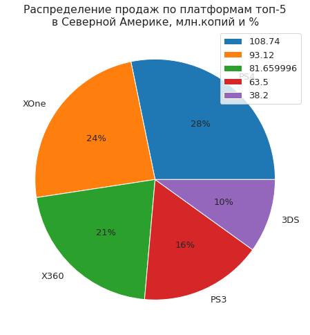

```python
X = top_platform_na_all['na_sales']
plt.subplots(figsize=(8, 8))
plt.pie(X, labels=top_platform_na_all['platform'], autopct='%1.0f%%')
plt.title('Распределение продаж по платформaм топ-5\nв Северной Америке, млн.копий и %')
plt.legend(X)
plt.show()
```

```
  platform  na_sales
0      PS4       294
1     XOne       227
2      PS3       211
3     X360       170
4      3DS       119
```

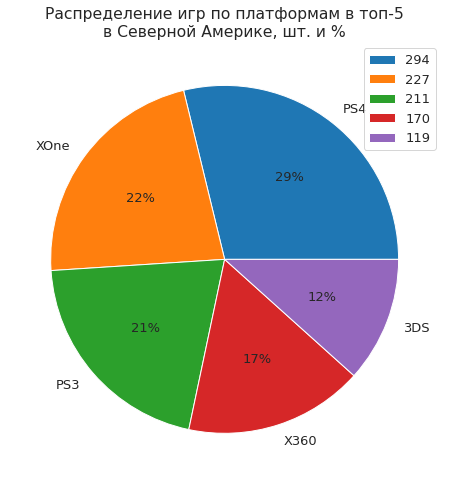

```python
top_platform_na_count = df_prediction_na.groupby('platform').agg({'na_sales': 'count'}).sort_values(by  = 'na_sales',
                                                                                                    ascending = False).reset_index()
list = ['PS4', 'XOne', 'X360', 'PS3', '3DS']
X_na = top_platform_na_count.query('platform == list')
print(X_na)

plt.subplots(figsize=(8,8))
plt.pie(X_na['na_sales'], labels=X_na['platform'], autopct='%1.0f%%')
plt.title('Распределение игр по платформам в топ-5\nв Северной Америке, шт. и %')
plt.legend(X_na['na_sales'])
plt.show()
```

Построим столбчатые диаграммы, где отобразим доли продаж топ-5 каждой платформы от общих продаж всех платформ в Северной Америке и общих продаж каждой платформы в мире.

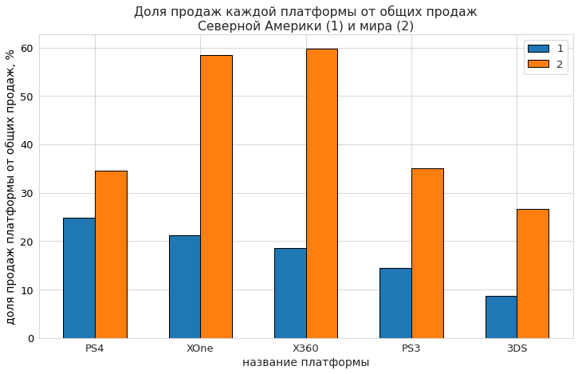

```python
fig, ax = plt.subplots(figsize = (12,7))
x = np.arange(len(top_platform_na_all))
width = 0.3
color = 'tab:blue'
ax.set_ylabel('доля продаж платформы от общих продаж, %', color='black', fontsize=14)
ax.bar(x - 0.15, top_platform_na_all['percent_all_sales_na'], color=color, width=width, ec='black')
ax.tick_params(axis='y', labelcolor=color)
ax.set_xlabel('название платформы', fontsize=14)
ax.yaxis.grid(True)

color = 'tab:orange'
ax.bar(x + 0.15, top_platform_na_all['percent_all_sales'], color=color, width=width, ec='black')
ax.tick_params(axis='y', labelcolor='black')
plt.rcParams['font.size'] = '13'
plt.xticks(top_platform_na_all.index, top_platform_na_all.platform)
plt.title('Доля продаж каждой платформы от общих продаж\nСеверной Америки (1) и мира (2)')
plt.legend('12')
plt.show()
```

```python
print('Доля продаж топ-5 платформ в Северной Америке от общих продаж в регионе, %:', top_platform_na_all['percent_all_sales_na'].sum().round(1))
```

```
Доля продаж топ-5 платформ в Северной Америке от общих продаж в регионе, %: 88.0
```

На североамериканском рынке самыми популярными платформами являются `PS4` и `XOne`, доли продаж которых составляют 25% и 21%, соответственно. Продажи от топ-5 платформ на рынке составляют 88% от всех продаж в данном регионе. Из графика и табличных данных видно, что продажи в Северной Америке вносят значительный вклад в общемировые продажи, так продажи `X360`, `XOne` составляют около 60% мировых продаж для каждой платформы, а `PS4` и `PS3` - около 35%. Топ-5 платформ в Северной Америке совпадает с топом-5 мировых платформ по продажам.

#### Европа (EU)

Сделаем аналогичные графики и посмотрим распределение топовых продаж по платформам Европы.

```python
df_prediction_eu = df_prediction.query('eu_sales > 0')
top_platform_eu = df_prediction_eu.groupby('platform').agg({'eu_sales' : 'sum', 'all_sales' : 'sum'}).sort_values(by  = 'eu_sales',
                                                                                         ascending = False).reset_index()
top_platform_eu['share_of_all_sales_eu'] = top_platform_eu['eu_sales'] / top_platform_eu['eu_sales'].sum() * 100
top_platform_eu = top_platform_eu[['platform', 'eu_sales', 'share_of_all_sales_eu']][:5]
print('Топовые платформы по продажам в EU:\n', top_platform_eu)
```

```
Топовые платформы по продажам в EU:
   platform  eu_sales  share_of_all_sales_eu
0      PS4    141.09                  35.97
1      PS3     67.81                  17.29
2     XOne     51.59                  13.15
3     X360     42.52                  10.84
4      3DS     30.96                   7.89
```

Топ-5 платформ по продажам в Европе: `PS4`, `PS3`, `XOne`, `X360`, `3DS`.

Создадим общую таблицу, куда включим данные доли продаж каждой платформы от общих продаж этой платформы в мире.

```python
top_platform_eu_all = top_platform_eu.merge(all_platform, on='platform', how='left')
top_platform_eu_all.columns = ['platform', 'eu_sales',
                               'percent_all_sales_eu', 'all_sales', 'percent_all_sales']
top_platform_eu_all['percent_all_sales'] = top_platform_eu_all['eu_sales'] / top_platform_eu_all['all_sales'] * 100
top_platform_eu_all
```

|  | platform | eu_sales | percent_all_sales_eu | all_sales | percent_all_sales |
| --- | --- | --- | --- | --- | --- |
| 0 | PS4 | 141.09 | 35.97 | 314.14 | 44.91 |
| 1 | PS3 | 67.81 | 17.29 | 181.43 | 37.38 |
| 2 | XOne | 51.59 | 13.15 | 159.32 | 32.38 |
| 3 | X360 | 42.52 | 10.84 | 136.80 | 31.08 |
| 4 | 3DS | 30.96 | 7.89 | 143.25 | 21.61 |

Построим круговую диаграмму и посмотрим на распределение количества игр в топ-5 платформaх в Европе.

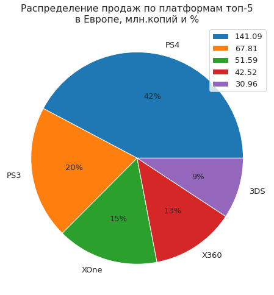

```python
plt.subplots(figsize=(8, 8))
plt.pie(top_platform_eu_all['eu_sales'], labels=top_platform_eu_all['platform'], autopct='%1.0f%%')
plt.title('Распределение продаж по платформaм топ-5\nв Европе, млн.копий и %')
plt.legend(top_platform_eu_all['eu_sales'])
plt.show()
```

```
  platform  eu_sales
0      PS4       290
1     XOne       218
2      PS3       212
4     X360       169
5      3DS       122
```

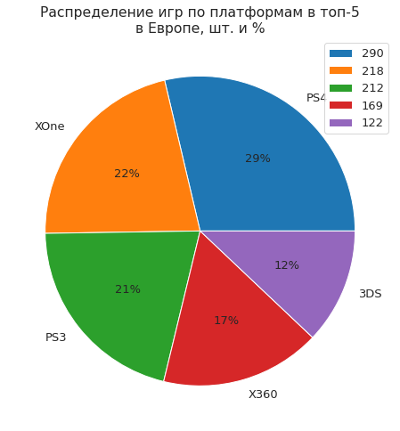

```python
top_platform_eu_count = df_prediction_eu.groupby('platform').agg({'eu_sales': 'count'}).sort_values(by  = 'eu_sales',
                                                                                                    ascending = False).reset_index()

list = ['PS4', 'PS3', 'XOne', 'X360', '3DS']
X_eu = top_platform_eu_count.query('platform == list')
print(X_eu)

plt.subplots(figsize=(8,8))
plt.pie(X_eu['eu_sales'], labels=X_eu['platform'], autopct='%1.0f%%')
plt.title('Распределение игр по платформам в топ-5\nв Европе, шт. и %')
plt.legend(X_eu['eu_sales'])
plt.show()
```

В топе-5 42% составляет `PS4` платформа, которая является самой популярной в Европе.

Построим столбчатые диаграммы, где отобразим доли продаж каждой платформы от общих продаж всех платформ в Европе и общих продаж каждой платформы в мире.

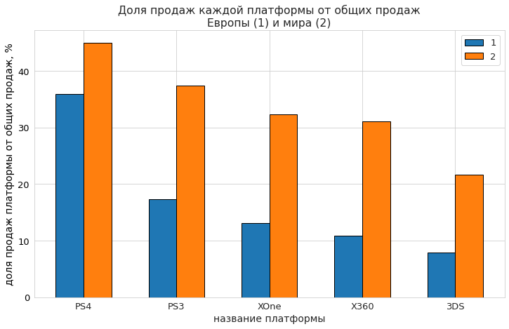

```python
fig, ax = plt.subplots(figsize = (12,7))
width = 0.3
color = 'tab:blue'
ax.set_ylabel('доля продаж платформы от общих продаж, %', color='black', fontsize=14)
ax.bar(x - 0.15, top_platform_eu_all['percent_all_sales_eu'], color=color, width=width, ec='black')
ax.tick_params(axis='y', labelcolor=color)
ax.set_xlabel('название платформы', fontsize=14)
ax.yaxis.grid(True)

color = 'tab:orange'
ax.bar(x + 0.15, top_platform_eu_all['percent_all_sales'], color=color, width=width, ec='black')
ax.tick_params(axis='y', labelcolor='black')
plt.rcParams['font.size'] = '13'
plt.xticks(top_platform_eu_all.index, top_platform_eu_all.platform)
plt.title('Доля продаж каждой платформы от общих продаж\nЕвропы (1) и мира (2)')
plt.legend('12')
plt.show()
```

```python
print('Доля продаж топ-5 платформ в Европе от общих продаж в регионе, %:', top_platform_eu_all['percent_all_sales_eu'].sum().round(1))
```

```
Доля продаж топ-5 платформ в Европе от общих продаж в регионе, %: 85.1
```

Топ-5 платформ в Европе также совпадает с топом-5 мировых продаж по платформам. Самой популярной платформой является `PS4`, 36 % - доля на рынке Европы. Продажи от топ-5 платформ на рынке составляют 85% от всех продаж в данном регионе. Все платформы вносят значительный вклад в общемировые продажи - от 22(`3DS`) до 45% (`PS4`).

#### Япония (JP)

```python
df_prediction_jp = df_prediction.query('jp_sales > 0')
top_platform_jp = df_prediction_jp.groupby('platform').agg({'jp_sales' : 'sum', 'all_sales' : 'sum'}).sort_values(by  = 'jp_sales',
                                                                                         ascending = False).reset_index()
top_platform_jp['share_of_all_sales_jp'] = top_platform_jp['jp_sales'] / top_platform_jp['jp_sales'].sum() * 100
top_platform_jp = top_platform_jp[['platform', 'jp_sales', 'share_of_all_sales_jp']][:5]
print('Топовые платформы по продажам в JP:\n', top_platform_jp)
```

```
Топовые платформы по продажам в JP:
   platform  jp_sales  share_of_all_sales_jp
0      3DS     67.81                  48.17
1      PS3     23.35                  16.59
2      PSV     18.59                  13.21
3      PS4     15.96                  11.34
4     WiiU     10.88                   7.73
```

Создадим общую таблицу, куда включим данные доли продаж каждой платформы от общих продаж этой платформы в мире.

```python
top_platform_jp_all = top_platform_jp.merge(all_platform, on='platform', how='left')
top_platform_jp_all.columns = ['platform', 'jp_sales', 'percent_all_sales_jp',
                               'all_sales', 'percent_all_sales']
top_platform_jp_all['percent_all_sales'] = top_platform_jp_all['jp_sales'] / top_platform_jp_all['all_sales'] * 100
top_platform_jp_all
```

|  | platform | jp_sales | percent_all_sales_jp | all_sales | percent_all_sales |
| --- | --- | --- | --- | --- | --- |
| 0 | 3DS | 67.81 | 48.17 | 143.25 | 47.34 |
| 1 | PS3 | 23.35 | 16.59 | 181.43 | 12.87 |
| 2 | PSV | 18.59 | 13.21 | 32.99 | 56.35 |
| 3 | PS4 | 15.96 | 11.34 | 314.14 | 5.08 |
| 4 | WiiU | 10.88 | 7.73 | 64.63 | 16.83 |

Построим круговую диаграмму и посмотрим на распределение количества игр в топ-5 платформaх в Японии.

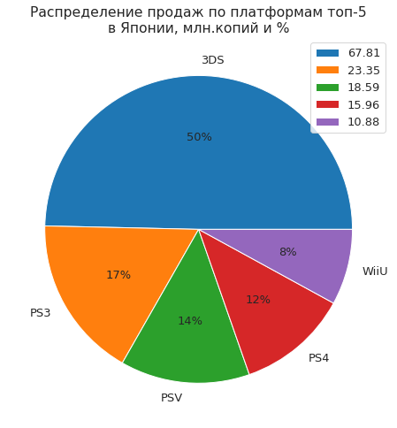

```python
X = top_platform_jp_all['jp_sales']
plt.subplots(figsize=(8, 8))
plt.pie(X, labels=top_platform_jp_all['platform'], autopct='%1.0f%%')
plt.title('Распределение продаж по платформaм топ-5\nв Японии, млн.копий и %')
plt.legend(X)
plt.show()
```

```
  platform  jp_sales
0      PSV       316
1      PS3       236
2      3DS       235
3      PS4       223
5     WiiU        57
```

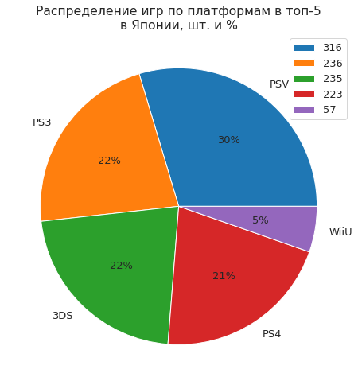

```python
top_platform_jp_count = df_prediction_jp.groupby('platform').agg({'jp_sales': 'count'}).sort_values(by  = 'jp_sales',
                                                                                                    ascending = False).reset_index()
list = ['PS4', 'PS3', 'WiiU', 'PSV', '3DS']
X_jp = top_platform_jp_count.query('platform == list')
print(X_jp)

plt.subplots(figsize=(8,8))
plt.pie(X_jp['jp_sales'], labels=X_jp['platform'], autopct='%1.0f%%')
plt.title('Распределение игр по платформам в топ-5\nв Японии, шт. и %')
plt.legend(X_jp['jp_sales'])
plt.show()
```

Построим столбчатые диаграммы, где отобразим доли продаж каждой платформы от общих продаж всех платформ в Японии и общих продаж каждой платформы в мире.

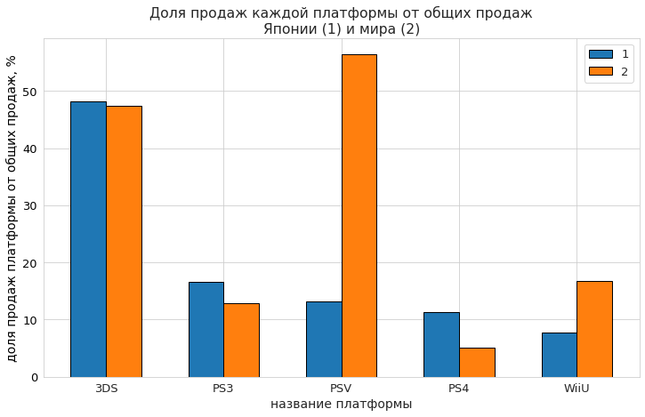

```python
fig, ax = plt.subplots(figsize = (12,7))
width = 0.3
color = 'tab:blue'
ax.set_ylabel('доля продаж платформы от общих продаж, %', color='black', fontsize=14)
ax.bar(x - 0.15, top_platform_jp_all['percent_all_sales_jp'], color=color, width=width, ec='black')
ax.tick_params(axis='y', labelcolor=color)
ax.set_xlabel('название платформы', fontsize=14)
ax.yaxis.grid(True)

color = 'tab:orange'
ax.bar(x + 0.15, top_platform_jp_all['percent_all_sales'], color=color, width=width, ec='black')
ax.tick_params(axis='y', labelcolor='black')
plt.rcParams['font.size'] = '13'
plt.xticks(top_platform_jp_all.index, top_platform_jp_all.platform)
plt.title('Доля продаж каждой платформы от общих продаж\nЯпонии (1) и мира (2)')
plt.legend('12')
plt.show()
```

```python
print('Доля продаж топ-5 платформ в Японии от общих продаж в регионе, %:', top_platform_jp_all['percent_all_sales_jp'].sum().round(1))
```

```
Доля продаж топ-5 платформ в Японии от общих продаж в регионе, %: 97.0
```

Посмотрим на распределение суммарных продаж платформ между регионами.

```python
# нужен цикл для вывода кол-ва и % - вклад каждого региона в общемировые продажи.
print('Суммарные продажи платформ в Европе, млн.шт:\n', top_platform_eu_all['eu_sales'].sum())
print('Суммарные продажи платформ  в Северной Америке, млн.шт:\n', top_platform_na_all['na_sales'].sum())
print('Суммарные продажи платформ в Японии, млн.шт:\n', top_platform_jp_all['jp_sales'].sum())
print('Суммарные продажи в мире, млн.шт:\n', df_prediction['all_sales'].sum())
```

```
Суммарные продажи платформ в Европе, млн.шт:
 333.96997
Суммарные продажи платформ  в Северной Америке, млн.шт:
 385.22
Суммарные продажи платформ в Японии, млн.шт:
 136.59
Суммарные продажи в мире, млн.шт:
 1090.6901
```

```python
a = pd.DataFrame(data = [['NA', 385.22],
                     ['EU', 333.97],
                     ['JP', 136.59],
                     ['others', 1090.69-385.22-333.97-136.59]],
             columns = ['region', 'total_sum'])
a
```

|  | region | total_sum |
| --- | --- | --- |
| 0 | NA | 385.22 |
| 1 | EU | 333.97 |
| 2 | JP | 136.59 |
| 3 | others | 234.91 |

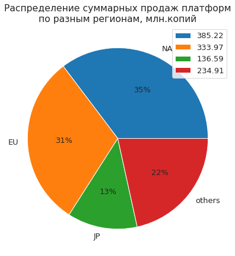

```python
plt.subplots(figsize=(7, 7))
plt.pie(a['total_sum'], labels=a['region'], autopct='%1.0f%%')
plt.title('Распределение суммарных продаж платформ\nпо разным регионам, млн.копий')
plt.legend(a['total_sum'])
plt.show()
```

### Самые популярные жанры (топ-5)

Посмотрим, как распределяются жанры по регионам. создадим таблицу `regions_genre_all`, куда включим данные по продажам в регионах, исходя из жанра.

В столбец `percent_all_sales` поместим долю каждого жанра от суммарных продаж жанра в мире.

`percent_(na,eu,jp)_sales` - доля продаж каждого жанра от продаж этого жанра в регионе.

`percent_(na,eu,jp)_all_sales` - доля продаж каждого жанра в регионе от общемировых продаж этого жанра.

```python
regions_genre_all = df_prediction.pivot_table(index = 'genre',
                                           values = ['na_sales','eu_sales','jp_sales','all_sales'],
                                           aggfunc = 'sum').sort_values(by  = 'all_sales',
                                                                        ascending = False).reset_index()
regions_genre_all['percent_all_sales'] = regions_genre_all['all_sales'] / regions_genre_all['all_sales'].sum() * 100
regions_genre_all['percent_eu_sales'] = regions_genre_all['eu_sales'] / regions_genre_all['eu_sales'].sum() * 100
regions_genre_all['percent_na_sales'] = regions_genre_all['na_sales'] / regions_genre_all['na_sales'].sum() * 100
regions_genre_all['percent_jp_sales'] = regions_genre_all['jp_sales'] / regions_genre_all['jp_sales'].sum() * 100
regions_genre_all['percent_eu_all_sales'] = regions_genre_all['eu_sales'] / regions_genre_all['all_sales'] * 100
regions_genre_all['percent_na_all_sales'] = regions_genre_all['na_sales'] / regions_genre_all['all_sales'] * 100
regions_genre_all['percent_jp_all_sales'] = regions_genre_all['jp_sales'] / regions_genre_all['all_sales'] * 100
regions_genre_all.T
```

|  | 0 | 1 | 2 | 3 | 4 | 5 | 6 | 7 | 8 | 9 | 10 | 11 |
| --- | --- | --- | --- | --- | --- | --- | --- | --- | --- | --- | --- | --- |
| genre | Action | Shooter | Sports | Role-Playing | Misc | Platform | Racing | Fighting | Adventure | Simulation | Strategy | Puzzle |
| all_sales | 321.87 | 232.98 | 150.65 | 145.89 | 62.82 | 42.63 | 39.89 | 35.31 | 23.64 | 21.76 | 10.08 | 3.17 |
| eu_sales | 118.13 | 87.86 | 60.52 | 36.97 | 20.04 | 15.58 | 20.19 | 8.55 | 8.25 | 10.92 | 4.22 | 1.00 |
| jp_sales | 40.49 | 6.61 | 5.41 | 51.04 | 9.20 | 4.79 | 2.30 | 7.65 | 5.82 | 4.52 | 1.77 | 1.18 |
| na_sales | 126.05 | 109.74 | 65.27 | 46.40 | 27.49 | 18.14 | 12.96 | 15.55 | 7.14 | 4.86 | 3.28 | 0.83 |
| percent_all_sales | 29.51 | 21.36 | 13.81 | 13.38 | 5.76 | 3.91 | 3.66 | 3.24 | 2.17 | 2.00 | 0.92 | 0.29 |
| percent_eu_sales | 30.12 | 22.40 | 15.43 | 9.43 | 5.11 | 3.97 | 5.15 | 2.18 | 2.10 | 2.78 | 1.08 | 0.25 |
| percent_na_sales | 28.80 | 25.07 | 14.91 | 10.60 | 6.28 | 4.14 | 2.96 | 3.55 | 1.63 | 1.11 | 0.75 | 0.19 |
| percent_jp_sales | 28.76 | 4.70 | 3.84 | 36.26 | 6.54 | 3.40 | 1.63 | 5.43 | 4.13 | 3.21 | 1.26 | 0.84 |
| percent_eu_all_sales | 36.70 | 37.71 | 40.17 | 25.34 | 31.90 | 36.55 | 50.61 | 24.21 | 34.90 | 50.18 | 41.87 | 31.55 |
| percent_na_all_sales | 39.16 | 47.10 | 43.33 | 31.80 | 43.76 | 42.55 | 32.49 | 44.04 | 30.20 | 22.33 | 32.54 | 26.18 |
| percent_jp_all_sales | 12.58 | 2.84 | 3.59 | 34.99 | 14.65 | 11.24 | 5.77 | 21.67 | 24.62 | 20.77 | 17.56 | 37.22 |

Самые популярные жанры в мире, топ-5: `Action`, `Shooter`, `Sports`, `Role-Playing`, `Misc`.

```python
top_regions_genre_all = regions_genre_all[:5]
top_regions_genre_all
```

|  | genre | all_sales | eu_sales | jp_sales | na_sales | percent_all_sales | percent_eu_sales | percent_na_sales | percent_jp_sales | percent_eu_all_sales | percent_na_all_sales | percent_jp_all_sales |
| --- | --- | --- | --- | --- | --- | --- | --- | --- | --- | --- | --- | --- |
| 0 | Action | 321.87 | 118.13 | 40.49 | 126.05 | 29.51 | 30.12 | 28.80 | 28.76 | 36.70 | 39.16 | 12.58 |
| 1 | Shooter | 232.98 | 87.86 | 6.61 | 109.74 | 21.36 | 22.40 | 25.07 | 4.70 | 37.71 | 47.10 | 2.84 |
| 2 | Sports | 150.65 | 60.52 | 5.41 | 65.27 | 13.81 | 15.43 | 14.91 | 3.84 | 40.17 | 43.33 | 3.59 |
| 3 | Role-Playing | 145.89 | 36.97 | 51.04 | 46.40 | 13.38 | 9.43 | 10.60 | 36.26 | 25.34 | 31.80 | 34.99 |
| 4 | Misc | 62.82 | 20.04 | 9.20 | 27.49 | 5.76 | 5.11 | 6.28 | 6.54 | 31.90 | 43.76 | 14.65 |

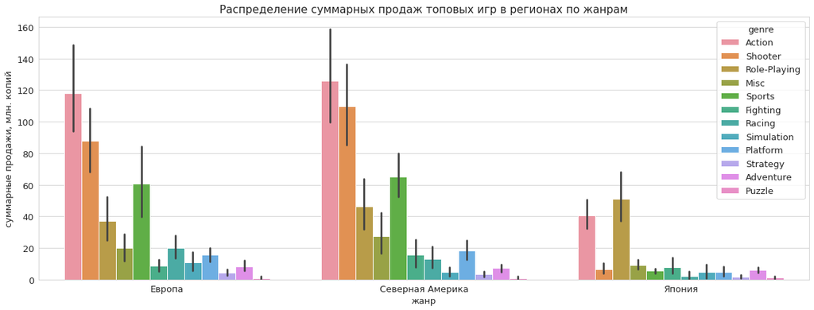

```python
regions_genre_melt = pd.melt(df_prediction, id_vars=['genre'], value_vars=['eu_sales', 'na_sales', 'jp_sales'])
regions_genre_melt.columns = ['genre', 'region', 'sales']
regions_genre_melt.replace({'eu_sales': 'Европа', 'jp_sales': 'Япония', 'na_sales': 'Северная Америка'}, inplace=True)

plt.figure(figsize=(20,7))
sns.barplot(data = regions_genre_melt, x='region', y='sales', hue='genre', estimator=sum)
sns.set_style("whitegrid")

plt.xlabel('жанр')
plt.ylabel('суммарные продажи, млн. копий')
plt.title('Распределение суммарных продаж топовых игр в регионах по жанрам')
plt.show()
```

Для Северной Америки и Европы самыми популярными жанрами являются `Action`, `Shooter`, `Sports`. Для Японии - `Role-Playing` и `Action`. Посмотрим более детально распределение по жанрам в этих регионах.

#### Северная Америка (NA)

Сгруппируем данные по жанрам в регионе NA, отортируем по убыванию, выделим топ-5 и создадим столбец, где расчитаем долю продаж каждого жанра от общих продаж в регионе.

```python
top_genre_na = regions_genre_all[['genre', 'na_sales',
                                  'percent_na_sales', 'percent_na_all_sales']].sort_values(by = 'na_sales',
                                                                                           ascending = False)[:5]
top_genre_na
```

|  | genre | na_sales | percent_na_sales | percent_na_all_sales |
| --- | --- | --- | --- | --- |
| 0 | Action | 126.05 | 28.80 | 39.16 |
| 1 | Shooter | 109.74 | 25.07 | 47.10 |
| 2 | Sports | 65.27 | 14.91 | 43.33 |
| 3 | Role-Playing | 46.40 | 10.60 | 31.80 |
| 4 | Misc | 27.49 | 6.28 | 43.76 |

Построим графики.

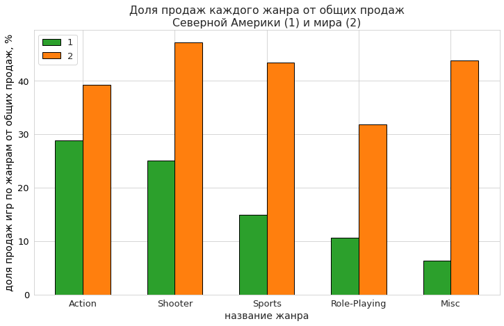

```python
fig, ax = plt.subplots(figsize = (12,7))
width = 0.3
color = 'tab:green'
ax.set_ylabel('доля продаж игр по жанрам от общих продаж, %', color='black', fontsize=14)
ax.bar(x - 0.15, top_genre_na['percent_na_sales'], color=color, width=width, ec='black')
ax.tick_params(axis='y', labelcolor=color)
ax.set_xlabel('название жанра', fontsize=14)
ax.yaxis.grid(True)

color = 'tab:orange'
ax.bar(x + 0.15, top_genre_na['percent_na_all_sales'], color=color, width=width, ec='black')
ax.tick_params(axis='y', labelcolor='black')
plt.rcParams['font.size'] = '13'
plt.xticks(top_genre_na.index, top_genre_na.genre)
plt.title('Доля продаж каждого жанра от общих продаж\nСеверной Америки (1) и мира (2)')
plt.legend('12')
plt.show()
```

```python
lst_top_na = ['Action', 'Shooter', 'Sports', 'Role-Playing', 'Misc']
top_genre_na_count = df_prediction.query('genre in @lst_top_na & na_sales > 0').groupby('genre')['na_sales'].count()
top_genre_na_count
```

```
genre
Action          442
Misc             84
Role-Playing    158
Shooter         171
Sports          143
Name: na_sales, dtype: int64
```

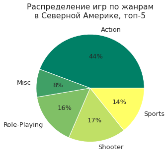

```python
top_genre_na_count.plot(figsize=(20,5), kind='pie', label='', cmap='summer',
                        autopct='%.0f%%').set_title('Распределение игр по жанрам\nв Северной Америке, топ-5')
plt.show()
```

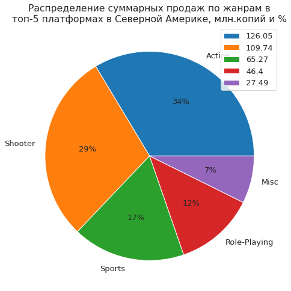

```python
plt.subplots(figsize=(8, 8))
plt.pie(top_genre_na['na_sales'], labels=top_genre_na['genre'], autopct='%1.0f%%')
plt.title('Распределение суммарных продаж по жанрам в\nтоп-5 платформaх в Северной Америке, млн.копий и %')
plt.legend(top_genre_na['na_sales'])
plt.show()
```

```python
print('Доля продаж топ-5 жанров в Северной Америке от общих продаж в регионе, %:', top_genre_na['percent_na_sales'].sum().round(1))
```

```
Доля продаж топ-5 жанров в Северной Америке от общих продаж в регионе, %: 85.7
```

Самые популярные жанры для региона: `Action` и `Shooter`. Доля продаж от всех продаж в регионе: 29 и 25%, соответственно. Вклад `Shooter` в мировые продажи - 47%, `Misc` - 44%, `Sports` - 43%. Все жанры топа-5 составляют больше 30% от мировых продаж. Для Северной Америки топ-5 популярных жанров совпадает с мировым.

#### Европа (EU)

```python
top_genre_eu = regions_genre_all[['genre', 'eu_sales',
                                  'percent_eu_sales', 'percent_eu_all_sales']].sort_values(by = 'eu_sales',
                                                                                           ascending = False).reset_index()[:5]
top_genre_eu
```

|  | index | genre | eu_sales | percent_eu_sales | percent_eu_all_sales |
| --- | --- | --- | --- | --- | --- |
| 0 | 0 | Action | 118.13 | 30.12 | 36.70 |
| 1 | 1 | Shooter | 87.86 | 22.40 | 37.71 |
| 2 | 2 | Sports | 60.52 | 15.43 | 40.17 |
| 3 | 3 | Role-Playing | 36.97 | 9.43 | 25.34 |
| 4 | 6 | Racing | 20.19 | 5.15 | 50.61 |

Построим графики.

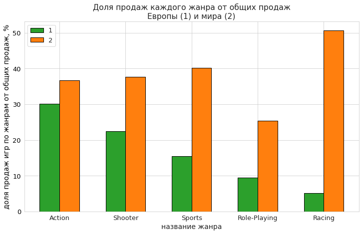

```python
fig, ax = plt.subplots(figsize = (12,7))
x = np.arange(len(top_genre_eu))
width = 0.3
color = 'tab:green'
ax.set_ylabel('доля продаж игр по жанрам от общих продаж, %', color='black', fontsize=14)
ax.bar(x - 0.15, top_genre_eu['percent_eu_sales'], color=color, width=width, ec='black')
ax.tick_params(axis='y', labelcolor=color)
ax.set_xlabel('название жанра', fontsize=14)
ax.yaxis.grid(True)

color = 'tab:orange'
ax.bar(x + 0.15, top_genre_eu['percent_eu_all_sales'], color=color, width=width, ec='black')
ax.tick_params(axis='y', labelcolor='black')
plt.rcParams['font.size'] = '13'
plt.xticks(top_genre_eu.index, top_genre_eu.genre)
plt.title('Доля продаж каждого жанра от общих продаж\nЕвропы (1) и мира (2)')
plt.legend('12')
plt.show()
```

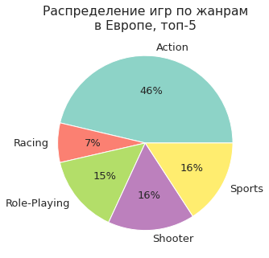

```python
lst_top_eu = ['Action', 'Shooter', 'Sports', 'Role-Playing', 'Racing']
top_genre_eu_count = df_prediction.query('genre in @lst_top_eu & eu_sales > 0').groupby('genre')['eu_sales'].count()
top_genre_eu_count.plot(figsize=(20,5), kind='pie', label='', cmap='Set3',
                        autopct='%.0f%%').set_title('Распределение игр по жанрам\nв Европе, топ-5')
plt.show()
```

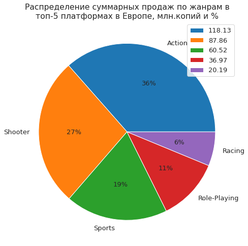

```python
plt.subplots(figsize=(8, 8))
plt.pie(top_genre_eu['eu_sales'], labels=top_genre_eu['genre'], autopct='%1.0f%%')
plt.title('Распределение суммарных продаж по жанрам в\nтоп-5 платформaх в Европе, млн.копий и %')
plt.legend(top_genre_eu['eu_sales'])
plt.show()
```

Самые популярные жанры для региона: Action и Shooter. Доля продаж от всех продаж в регионе: 30 и 22%, соответственно. Их вклад в мировые продажи - 37 и 38%, соответственно. Большой вклад в мировые продажи вносит жанр `Racing` - 51% при внутренних 5% продажах в Европе.

#### Япония (JP)

```python
top_genre_jp = regions_genre_all[['genre', 'jp_sales',
                                  'percent_jp_sales', 'percent_jp_all_sales']].sort_values(by = 'jp_sales',
                                                                                           ascending = False).reset_index()[:5]
top_genre_jp
```

|  | index | genre | jp_sales | percent_jp_sales | percent_jp_all_sales |
| --- | --- | --- | --- | --- | --- |
| 0 | 3 | Role-Playing | 51.04 | 36.26 | 34.99 |
| 1 | 0 | Action | 40.49 | 28.76 | 12.58 |
| 2 | 4 | Misc | 9.20 | 6.54 | 14.65 |
| 3 | 7 | Fighting | 7.65 | 5.43 | 21.67 |
| 4 | 1 | Shooter | 6.61 | 4.70 | 2.84 |

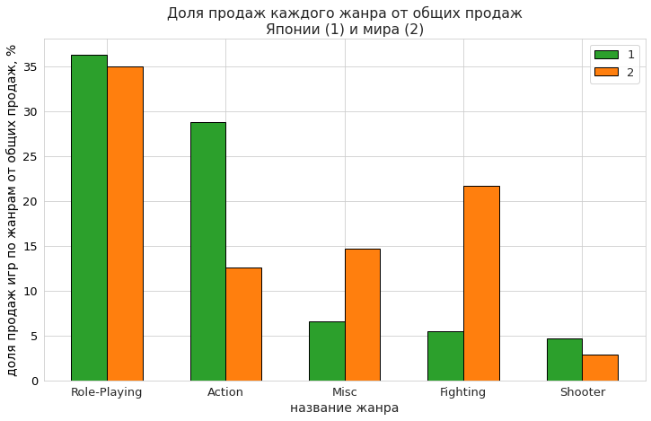

```python
fig, ax = plt.subplots(figsize = (12,7))
x = np.arange(len(top_genre_jp))
width = 0.3
color = 'tab:green'
ax.set_ylabel('доля продаж игр по жанрам от общих продаж, %', color='black', fontsize=14)
ax.bar(x - 0.15, top_genre_jp['percent_jp_sales'], color=color, width=width, ec='black')
ax.tick_params(axis='y', labelcolor=color)
ax.set_xlabel('название жанра', fontsize=14)
ax.yaxis.grid(True)

color = 'tab:orange'
ax.bar(x + 0.15, top_genre_jp['percent_jp_all_sales'], color=color, width=width, ec='black')
ax.tick_params(axis='y', labelcolor='black')
plt.rcParams['font.size'] = '13'
plt.xticks(top_genre_jp.index, top_genre_jp.genre)
plt.title('Доля продаж каждого жанра от общих продаж\nЯпонии (1) и мира (2)')
plt.legend('12')
plt.show()
```

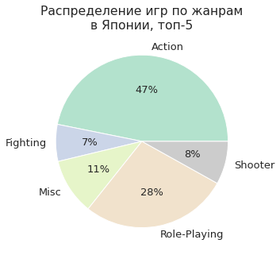

```python
lst_top_jp = ['Action', 'Shooter', 'Role-Playing', 'Misc', 'Fighting']
top_genre_jp_count = df_prediction.query('genre in @lst_top_jp & jp_sales > 0').groupby('genre')['jp_sales'].count()
top_genre_jp_count.plot(figsize=(20,5), kind='pie', label='', cmap='Pastel2',
                        autopct='%.0f%%').set_title('Распределение игр по жанрам\nв Японии, топ-5')
plt.show()
```

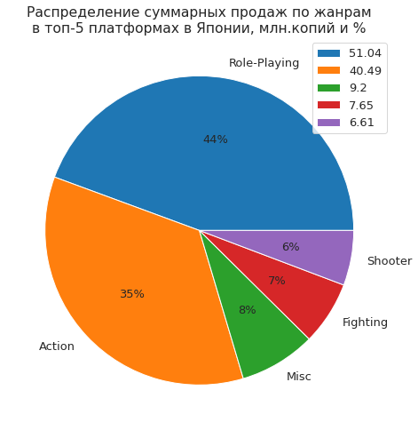

```python
plt.subplots(figsize=(8, 8))
plt.pie(top_genre_jp['jp_sales'], labels=top_genre_jp['genre'], autopct='%1.0f%%')
plt.title('Распределение суммарных продаж по жанрам\nв топ-5 платформaх в Японии, млн.копий и %')
plt.legend(top_genre_jp['jp_sales'])
plt.show()
```

В Японии жанр `Role-Playing` пользуется высокой популярностью: продажи этого жанра на внутреннем рынке составляют 36% от всех продаж в регионе, также и в мировом потреблении процент этого жанра от общих продаж составляет 35%. Также популярен жанр `Action`- 29% от продаж в Японии. Вкусовые предпочтения по жанрам также отличаются у японцев от Европы и Америки, жанр `Fighting`, к примеру, не вошел в топ-5 мира.